# Arterial hypertension

# 1 Description of DataSchema variable

The description of harmonised variable is the following:

- Short name: `ah`
- Variable label: `Arterial hypertension`
- Variable description: `Arterial hypertension. Means of all diastolic blood pressure measures.`
- Domain: `Physical Measures`
- Value type: `Categorical`
- Category coding:

| **Code** | **Category Label** |
| --- | --- |
| 0 | no hypertension |
| 1 | hypertension |

- Category missings:

| **Code** | **Category Label** |
| --- | --- |
| 991 | CAPI/interviewer error |
| 992 | Impute |
| 993 | Disable to measure |
| 994 | Not attempt/not done |
| 995 | Does not answer |
| 996 | Not applicable |
| 997 | Refuse |
| 998 | Do not know |
| 999 | Missing |

# 2 Data process

## 2.1 ELSA

### 2.1.1 Wave 1

There is no variable.

### 2.1.2 Wave 2

#### 2.1.2.1 Study-specific variable description

| **Name** | `sbp` | `dbp` |
| --- | --- | --- |
| **Label** | `Systolic blood pressure of participant at each wave` | `Diastolic blood pressure of participantat at each wave` |
| **Table name** | `sbp` | `dbp` |
| **Categories** | `continuous` | `continuous` |
| **Missings** | `991 = CAPI/interviewer error` | `991 = CAPI/interviewer error` |
|  | `992 = Impute` | `992 = Impute` |
|  | `993 = Disable to measure` | `993 = Disable to measure` |
|  | `994 = Not attempt/not done` | `994 = Not attempt/not done` |
|  | `995 = Does not answer` | `995 = Does not answer` |
|  | `996 = Not applicable` | `996 = Not applicable` |
|  | `997 = Refuse` | `997 = Refuse` |
|  | `998 = Do not know` | `998 = Do not know` |
|  | `999 = Missing` | `999 = Missing` |
| **Description** |  |  |

| Sample size | Missing values |
| --- | --- |
| 7666 | 105 |

Values

|  | No-missings | 991 | 992 | 993 | 994 | 995 | 996 | 997 | 998 | 999 | NA |
| --- | --- | --- | --- | --- | --- | --- | --- | --- | --- | --- | --- |
| Frequency | 7561.00 | 0 | 0 | 0 | 0 | 0 | 24.00 | 0 | 0 | 81.00 | 0 |
| Percentage | 98.63 | 0 | 0 | 0 | 0 | 0 | 0.31 | 0 | 0 | 1.06 | 0 |

Summary

[output not shown]

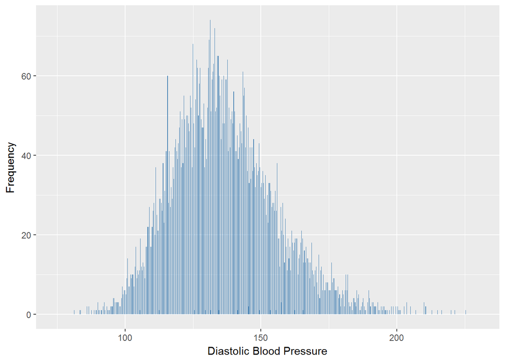

| Sample size | Missing values |
| --- | --- |
| 7666 | 103 |

Values

|  | No-missings | 991 | 992 | 993 | 994 | 995 | 996 | 997 | 998 | 999 | NA |
| --- | --- | --- | --- | --- | --- | --- | --- | --- | --- | --- | --- |
| Frequency | 7563.00 | 0 | 0 | 0 | 0 | 0 | 24.00 | 0 | 0 | 79.00 | 0 |
| Percentage | 98.66 | 0 | 0 | 0 | 0 | 0 | 0.31 | 0 | 0 | 1.03 | 0 |

Summary

| Min. | 1st Qu. | Median | Mean | 3rd Qu. | Max. |
| --- | --- | --- | --- | --- | --- |
| 32 | 68 | 75.5 | 75.76 | 83 | 128 |

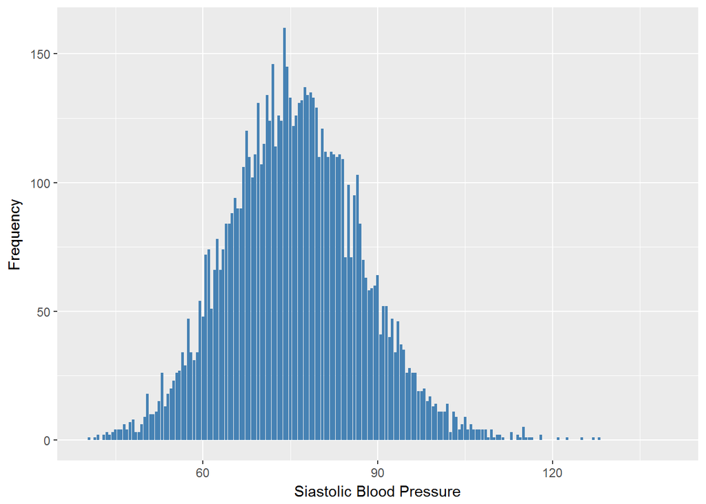

#### 2.1.2.2 Harmonisation algorithm

To compute the harmonized variable, first of all, it has to be created two categorical variables as follows:

- dh:
- `dbp >= 90 into 1`
- `dbp < 90 into 0`
- sh:
- `sbp>= 140 into 1`
- `sbp< 140 into 0`

After that, to compute the harmonized variable from this two variables has to be recoded as follows:

- `if dh = 0 and sh = 0 into 0`
- `if dh = 1 and sh = 0 into 1`
- `if dh = 0 and sh = 1 into 1`
- `if dh = 1 and sh = 1 into 1`
- `NA into 999`

**R script:**

```r
ELSA1_ah$dh <- car::recode(ELSA1_ah$dbp, "0:89.99999999=0; 90:900=1")
ELSA1_ah$sh <- car::recode(ELSA1_ah$sbp, "0:139.9999999=0; 140:900=1")

ELSA_ds_w2 <- tibble(id = ELSA1_ah$id)
ELSA_ds_w2$ah <- NA
ELSA_ds_w2$ah[which(ELSA1_ah$dh == 0 & ELSA1_ah$sh == 0)] <- 0
ELSA_ds_w2$ah[which(ELSA1_ah$dh == 1 & ELSA1_ah$sh == 0)] <- 1
ELSA_ds_w2$ah[which(ELSA1_ah$dh == 0 & ELSA1_ah$sh == 1)] <- 1
ELSA_ds_w2$ah[which(ELSA1_ah$dh == 1 & ELSA1_ah$sh == 1)] <- 1
ELSA_ds_w2$ah[which(ELSA1_ah$dh == 999 & ELSA1_ah$sh == 999)] <- 999
ELSA_ds_w2$ah[which(ELSA1_ah$dh == 996 & ELSA1_ah$sh == 996)] <- 996

ELSA_ds_w2$ah[which(ELSA1_ah$dh == 1 & ELSA1_ah$sh == 999)] <- 1
ELSA_ds_w2$ah[which(ELSA1_ah$dh == 999 & ELSA1_ah$sh == 0)] <- 999

ELSA_ds_w2$ah <- labelled(ELSA_ds_w2$ah, labels = c(`no hypertension` = 0, hypertension = 1,
    Missing = 999, `Do not know` = 998, Refuse = 997, `Not applicable` = 996,
    `Does not answer` = 995, `Not attempt not done` = 994, `Disable to measure` = 993,
    Impute = 992, `CAPI interviewer error` = 991))
```

#### 2.1.2.3 Statistics of the new harmonised variable

Arterial hypertension

| Sample size | Missing values |
| --- | --- |
| 7666 | 103 |

Category

|  | 0 | 1 |
| --- | --- | --- |
| Frequency | 4503.00 | 3060.00 |
| Percentage | 58.74 | 39.92 |

Type of missing

|  | 991 | 992 | 993 | 994 | 995 | 996 | 997 | 998 | 999 | NA |
| --- | --- | --- | --- | --- | --- | --- | --- | --- | --- | --- |
| Frequency | 0 | 0 | 0 | 0 | 0 | 24.00 | 0 | 0 | 79.00 | 0 |
| Percentage | 0 | 0 | 0 | 0 | 0 | 0.31 | 0 | 0 | 1.03 | 0 |

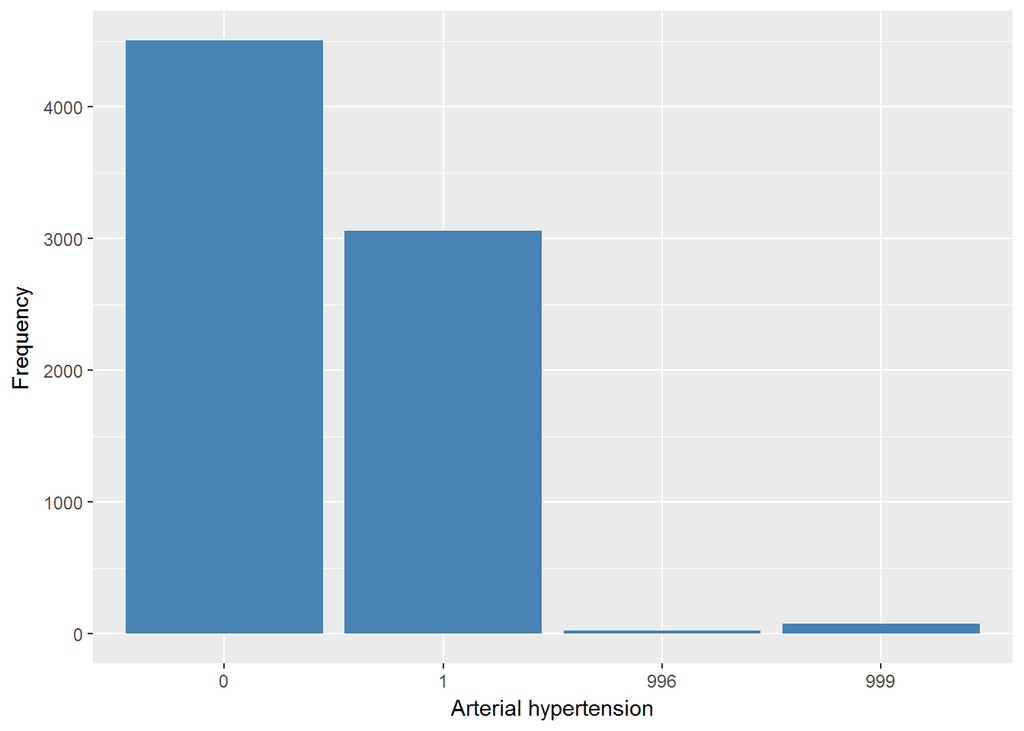

#### 2.1.2.4 Validation

### 2.1.3 Wave 3

There is no variable.

### 2.1.4 Wave 4

#### 2.1.4.1 Study-specific variable description

| **Name** | `sbp` | `dbp` |
| --- | --- | --- |
| **Label** | `Systolic blood pressure of participant at each wave` | `Diastolic blood pressure of participantat at each wave` |
| **Table name** | `sbp` | `dbp` |
| **Categories** | `continuous` | `continuous` |
| **Missings** | `991 = CAPI/interviewer error` | `991 = CAPI/interviewer error` |
|  | `992 = Impute` | `992 = Impute` |
|  | `993 = Disable to measure` | `993 = Disable to measure` |
|  | `994 = Not attempt/not done` | `994 = Not attempt/not done` |
|  | `995 = Does not answer` | `995 = Does not answer` |
|  | `996 = Not applicable` | `996 = Not applicable` |
|  | `997 = Refuse` | `997 = Refuse` |
|  | `998 = Do not know` | `998 = Do not know` |
|  | `999 = Missing` | `999 = Missing` |
| **Description** |  |  |

| Sample size | Missing values |
| --- | --- |
| 8643 | 110 |

Values

|  | No-missings | 991 | 992 | 993 | 994 | 995 | 996 | 997 | 998 | 999 | NA |
| --- | --- | --- | --- | --- | --- | --- | --- | --- | --- | --- | --- |
| Frequency | 8533.00 | 0 | 0 | 0 | 0 | 0 | 37.00 | 0 | 0 | 73.00 | 0 |
| Percentage | 98.73 | 0 | 0 | 0 | 0 | 0 | 0.43 | 0 | 0 | 0.84 | 0 |

Summary

| Min. | 1st Qu. | Median | Mean | 3rd Qu. | Max. |
| --- | --- | --- | --- | --- | --- |
| 81.67 | 121 | 132.3 | 133.5 | 144.3 | 225.7 |

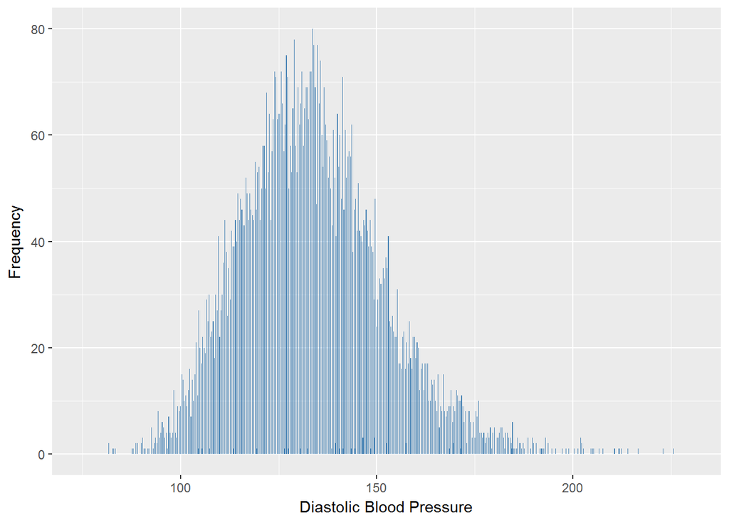

| Sample size | Missing values |
| --- | --- |
| 8643 | 106 |

Values

|  | No-missings | 991 | 992 | 993 | 994 | 995 | 996 | 997 | 998 | 999 | NA |
| --- | --- | --- | --- | --- | --- | --- | --- | --- | --- | --- | --- |
| Frequency | 8537.00 | 0 | 0 | 0 | 0 | 0 | 37.00 | 0 | 0 | 69.0 | 0 |
| Percentage | 98.77 | 0 | 0 | 0 | 0 | 0 | 0.43 | 0 | 0 | 0.8 | 0 |

Summary

| Min. | 1st Qu. | Median | Mean | 3rd Qu. | Max. |
| --- | --- | --- | --- | --- | --- |
| 37.5 | 67.5 | 74.5 | 74.92 | 82 | 122.5 |

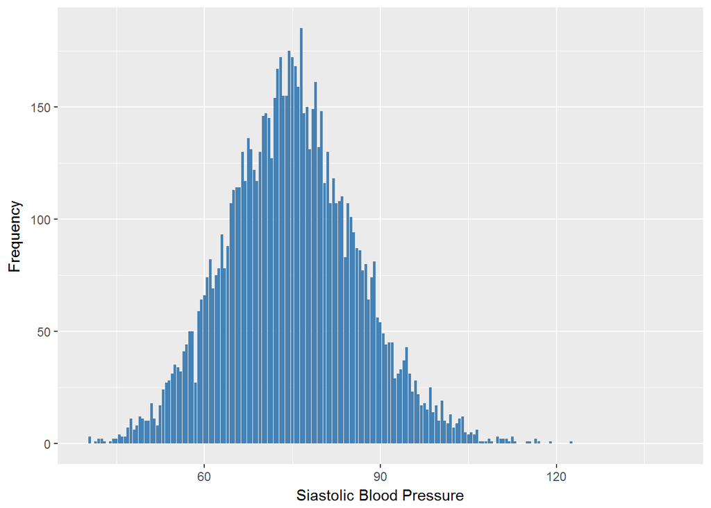

#### 2.1.4.2 Harmonisation algorithm

To compute the harmonized variable, first of all, it has to be created two categorical variables as follows:

- dh:
- `dbp >= 90 into 1`
- `dbp < 90 into 0`
- sh:
- `sbp>= 140 into 1`
- `sbp< 140 into 0`

After that, to compute the harmonized variable from this two variables has to be recoded as follows:

- `if dh = 0 and sh = 0 into 0`
- `if dh = 1 and sh = 0 into 1`
- `if dh = 0 and sh = 1 into 1`
- `if dh = 1 and sh = 1 into 1`
- `NA into 999`

**R script:**

```r
ELSA2_ah$dh <- car::recode(ELSA2_ah$dbp, "0:89.99999999=0; 90:900=1")
ELSA2_ah$sh <- car::recode(ELSA2_ah$sbp, "0:139.9999999=0; 140:900=1")

ELSA_ds_w4 <- tibble(id = ELSA2_ah$id)
ELSA_ds_w4$ah <- NA
ELSA_ds_w4$ah[which(ELSA2_ah$dh == 0 & ELSA2_ah$sh == 0)] <- 0
ELSA_ds_w4$ah[which(ELSA2_ah$dh == 1 & ELSA2_ah$sh == 0)] <- 1
ELSA_ds_w4$ah[which(ELSA2_ah$dh == 0 & ELSA2_ah$sh == 1)] <- 1
ELSA_ds_w4$ah[which(ELSA2_ah$dh == 1 & ELSA2_ah$sh == 1)] <- 1
ELSA_ds_w4$ah[which(ELSA2_ah$dh == 999 & ELSA2_ah$sh == 999)] <- 999
ELSA_ds_w4$ah[which(ELSA2_ah$dh == 996 & ELSA2_ah$sh == 996)] <- 996

ELSA_ds_w4$ah[which(ELSA2_ah$dh == 0 & ELSA2_ah$sh == 999)] <- 999

ELSA_ds_w4$ah <- labelled(ELSA_ds_w4$ah, labels = c(`no hypertension` = 0, hypertension = 1,
    Missing = 999, `Do not know` = 998, Refuse = 997, `Not applicable` = 996,
    `Does not answer` = 995, `Not attempt not done` = 994, `Disable to measure` = 993,
    Impute = 992, `CAPI interviewer error` = 991))
```

#### 2.1.4.3 Statistics of the new harmonised variable

Arterial hypertension

| Sample size | Missing values |
| --- | --- |
| 8643 | 110 |

Category

|  | 0 | 1 |
| --- | --- | --- |
| Frequency | 5538.00 | 2995.00 |
| Percentage | 64.07 | 34.65 |

Type of missing

|  | 991 | 992 | 993 | 994 | 995 | 996 | 997 | 998 | 999 | NA |
| --- | --- | --- | --- | --- | --- | --- | --- | --- | --- | --- |
| Frequency | 0 | 0 | 0 | 0 | 0 | 37.00 | 0 | 0 | 73.00 | 0 |
| Percentage | 0 | 0 | 0 | 0 | 0 | 0.43 | 0 | 0 | 0.84 | 0 |

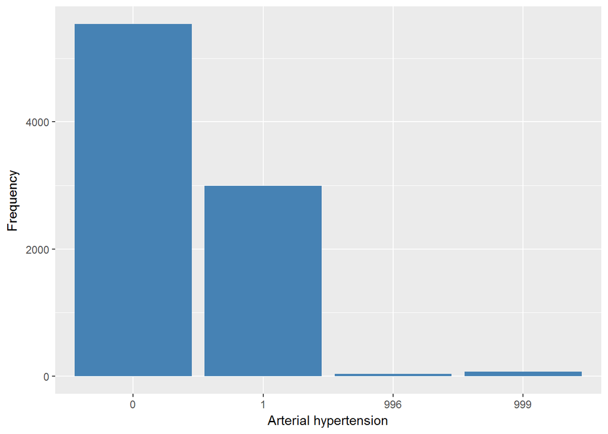

#### 2.1.4.4 Validation

### 2.1.5 Wave 5

There is no variable.

### 2.1.6 Wave 6

#### 2.1.6.1 Study-specific variable description

| **Name** | `sbp` | `dbp` |
| --- | --- | --- |
| **Label** | `Systolic blood pressure of participant at each wave` | `Diastolic blood pressure of participantat at each wave` |
| **Table name** | `sbp` | `dbp` |
| **Categories** | `continuous` | `continuous` |
| **Missings** | `991 = CAPI/interviewer error` | `991 = CAPI/interviewer error` |
|  | `992 = Impute` | `992 = Impute` |
|  | `993 = Disable to measure` | `993 = Disable to measure` |
|  | `994 = Not attempt/not done` | `994 = Not attempt/not done` |
|  | `995 = Does not answer` | `995 = Does not answer` |
|  | `996 = Not applicable` | `996 = Not applicable` |
|  | `997 = Refuse` | `997 = Refuse` |
|  | `998 = Do not know` | `998 = Do not know` |
|  | `999 = Missing` | `999 = Missing` |
| **Description** |  |  |

| Sample size | Missing values |
| --- | --- |
| 8054 | 80 |

Values

|  | No-missings | 991 | 992 | 993 | 994 | 995 | 996 | 997 | 998 | 999 | NA |
| --- | --- | --- | --- | --- | --- | --- | --- | --- | --- | --- | --- |
| Frequency | 7974.00 | 0 | 0 | 0 | 0 | 0 | 25.00 | 0 | 0 | 55.00 | 0 |
| Percentage | 99.01 | 0 | 0 | 0 | 0 | 0 | 0.31 | 0 | 0 | 0.68 | 0 |

Summary

[output not shown]

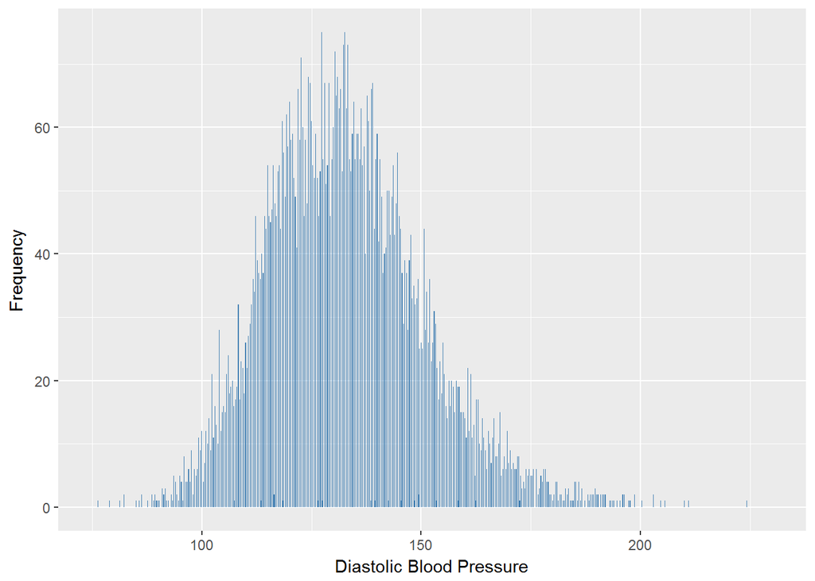

| Sample size | Missing values |
| --- | --- |
| 8054 | 80 |

Values

|  | No-missings | 991 | 992 | 993 | 994 | 995 | 996 | 997 | 998 | 999 | NA |
| --- | --- | --- | --- | --- | --- | --- | --- | --- | --- | --- | --- |
| Frequency | 7974.00 | 0 | 0 | 0 | 0 | 0 | 25.00 | 0 | 0 | 55.00 | 0 |
| Percentage | 99.01 | 0 | 0 | 0 | 0 | 0 | 0.31 | 0 | 0 | 0.68 | 0 |

Summary

| Min. | 1st Qu. | Median | Mean | 3rd Qu. | Max. |
| --- | --- | --- | --- | --- | --- |
| 35.5 | 67 | 74 | 74.21 | 81.5 | 125 |

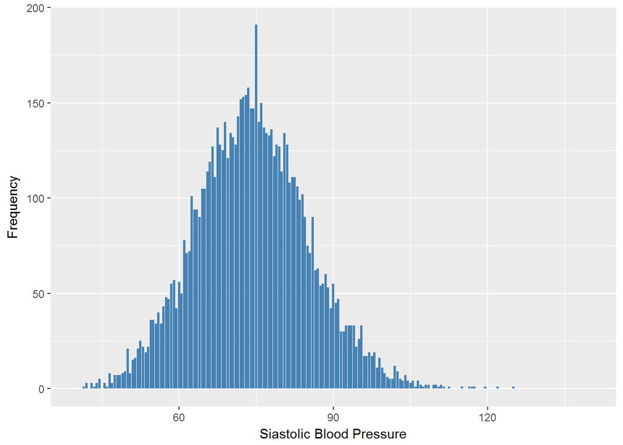

#### 2.1.6.2 Harmonisation algorithm

To compute the harmonized variable, first of all, it has to be created two categorical variables as follows:

- dh:
- `dbp >= 90 into 1`
- `dbp < 90 into 0`
- sh:
- `sbp>= 140 into 1`
- `sbp< 140 into 0`

After that, to compute the harmonized variable from this two variables has to be recoded as follows:

- `if dh = 0 and sh = 0 into 0`
- `if dh = 1 and sh = 0 into 1`
- `if dh = 0 and sh = 1 into 1`
- `if dh = 1 and sh = 1 into 1`
- `NA into 999`

**R script:**

```r
ELSA3_ah$dh <- car::recode(ELSA3_ah$dbp, "0:89.99999999=0; 90:900=1")
ELSA3_ah$sh <- car::recode(ELSA3_ah$sbp, "0:139.9999999=0; 140:900=1")

ELSA_ds_w6 <- tibble(id = ELSA3_ah$id)
ELSA_ds_w6$ah <- NA
ELSA_ds_w6$ah[which(ELSA3_ah$dh == 0 & ELSA3_ah$sh == 0)] <- 0
ELSA_ds_w6$ah[which(ELSA3_ah$dh == 1 & ELSA3_ah$sh == 0)] <- 1
ELSA_ds_w6$ah[which(ELSA3_ah$dh == 0 & ELSA3_ah$sh == 1)] <- 1
ELSA_ds_w6$ah[which(ELSA3_ah$dh == 1 & ELSA3_ah$sh == 1)] <- 1
ELSA_ds_w6$ah[which(ELSA3_ah$dh == 999 & ELSA3_ah$sh == 999)] <- 999
ELSA_ds_w6$ah[which(ELSA3_ah$dh == 996 & ELSA3_ah$sh == 996)] <- 996
ELSA_ds_w6$ah <- labelled(ELSA_ds_w6$ah, labels = c(`no hypertension` = 0, hypertension = 1,
    Missing = 999, `Do not know` = 998, Refuse = 997, `Not applicable` = 996,
    `Does not answer` = 995, `Not attempt not done` = 994, `Disable to measure` = 993,
    Impute = 992, `CAPI interviewer error` = 991))
```

#### 2.1.6.3 Statistics of the new harmonised variable

Arterial hypertension

| Sample size | Missing values |
| --- | --- |
| 8054 | 80 |

Category

|  | 0 | 1 |
| --- | --- | --- |
| Frequency | 5353.00 | 2621.00 |
| Percentage | 66.46 | 32.54 |

Type of missing

|  | 991 | 992 | 993 | 994 | 995 | 996 | 997 | 998 | 999 | NA |
| --- | --- | --- | --- | --- | --- | --- | --- | --- | --- | --- |
| Frequency | 0 | 0 | 0 | 0 | 0 | 25.00 | 0 | 0 | 55.00 | 0 |
| Percentage | 0 | 0 | 0 | 0 | 0 | 0.31 | 0 | 0 | 0.68 | 0 |

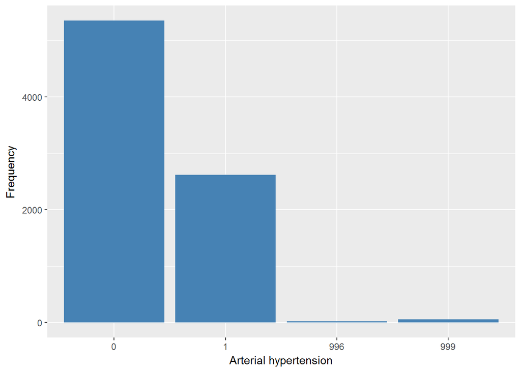

#### 2.1.6.4 Validation

### 2.1.7 Wave 7

There is no variable.

# 3 Quality estimation